# Intro2R

Jonathan Rosenblatt

March 18, 2015

# Preliminaries:

- Make sure you use RStudio.
- alt+shift+k for RStudio keyboard shortcuts.
- ctrl+return to run lines from editor.
- ctrl+alt+j to navigate between sections
- tab for autocompletion
- ctrl+1 to skip to editor.
- ctrl+2 to skip to console.

# Simple calculator

```r
10+5
```

```
## [1] 15
```

```r
70*81
```

```
## [1] 5670
```

```r
2**4
```

```
## [1] 16
```

```r
2^4
```

```
## [1] 16
```

```r
log(10)
```

```
## [1] 2.303
```

```r
log(16, 2)
```

```
## [1] 4
```

```r
log(1000, 10)
```

```
## [1] 3
```

# Controlling output format:

```r
round(log(10))
```

```
## [1] 2
```

```r
signif(log(10))
```

```
## [1] 2.303
```

```r
prettyNum(log(10), digits=5)
```

```
## [1] "2.3026"
```

```r
format(log(10), digits=4, scientific=T, justify='right')
```

```
## [1] "2.303e+00"
```

# Probability calculator

Wish you knew this when you did Intro To Probability class?

```r
dbinom(x=3, size=10, prob=0.5)  # For X~B(n=10, p=0.5) returns P(X=3)
```

```
## [1] 0.1172
```

```r
dbinom(3, 10, 0.5)
```

```
## [1] 0.1172
```

```r
pbinom(q=3, size=10, prob=0.5) # For X~B(n=10, p=0.5) returns P(X<=3)
```

```
## [1] 0.1719
```

```r
dbinom(x=0, size=10, prob=0.5)+dbinom(x=1, size=10, prob=0.5)+dbinom(x=2, size=10, prob=0.5)+dbinom(x=3, size=10, prob=0.5) # Same as previous
```

```
## [1] 0.1719
```

```r
qbinom(p=0.1718, size=10, prob=0.5) # For X~B(n=10, p=0.5) returns k such that P(X<=k)=0.1718
```

```
## [1] 3
```

```r
rbinom(n=1, size=10, prob=0.5)
```

```
## [1] 4
```

```r
rbinom(n=10, size=10, prob=0.5)
```

```
##  [1] 6 4 5 6 5 1 5 5 7 4
```

```r
rbinom(n=100, size=10, prob=0.5)
```

```
##   [1] 5 4 6 6 3 4 3 7 5 6 5 3 4 6 1 6 5 1 5 7 5 5 4 4 3 5 7 3 7 8 6 6 3 4 5
##  [36] 7 4 6 4 7 5 4 5 5 2 7 4 3 8 7 3 4 5 6 5 6 3 5 2 2 3 5 6 4 3 7 4 3 5 5
##  [71] 5 4 3 3 5 7 4 6 6 7 2 3 4 5 4 6 3 6 4 7 6 4 4 7 5 8 5 5 2 3
```

# Getting help

Get help for a particular function.

```r
?dbinom
help(dbinom)
```

Search local help files for a particular string.

```r
??binomial
help.search('dbinom')
```

Load a menu with several important manuals:

```r
help.start()
```

# Variable asignment:

Asignments into a variable named “x”:

```r
x = rbinom(n=1000, size=10, prob=0.5) # Works. Bad style.
x <- rbinom(n=1000, size=10, prob=0.5) # Asignments into a variable named "x"
```

Print contents:

```r
x
```

```
##    [1] 4 7 4 6 6 5 1 8 4 4 5 6 6 4 4 5 5 6 6 7 4 6 4 4 7 6 4 6 4 5 7 4 5 3
##   [35] 8 4 5 7 5 7 5 4 8 6 5 7 7 7 6 4 5 3 6 4 6 5 4 2 3 5 3 5 4 6 5 4 4 8
##   [69] 2 7 7 4 6 6 6 4 6 4 4 4 6 6 1 4 7 4 7 5 3 6 7 4 4 6 6 4 6 5 7 9 3 5
##  [103] 1 6 9 3 7 5 7 4 5 8 4 6 8 5 5 4 5 5 8 4 8 7 2 6 3 7 6 4 4 3 3 6 6 6
##  [137] 3 3 6 6 3 6 5 3 7 3 5 6 4 6 3 7 6 5 5 6 7 5 6 3 6 5 4 3 7 5 6 6 4 4
##  [171] 4 7 5 6 6 4 6 3 6 5 5 6 4 6 2 3 5 3 5 2 7 3 6 4 4 3 2 5 6 6 7 3 5 4
##  [205] 6 6 4 6 6 4 7 6 4 1 6 4 3 2 6 4 7 5 6 5 4 6 3 3 6 6 5 5 4 5 4 7 4 5
##  [239] 7 6 3 7 8 3 5 5 4 7 4 4 4 4 7 7 5 3 5 7 5 4 4 7 3 3 4 6 5 4 4 5 5 5
##  [273] 7 6 6 5 5 5 8 1 5 8 3 4 7 5 7 3 7 6 4 6 3 4 4 6 4 5 7 8 4 4 4 4 7 5
##  [307] 8 2 3 5 4 6 4 8 6 7 6 4 4 5 3 5 6 4 4 5 3 6 6 6 1 3 5 2 8 6 7 7 6 6
##  [341] 5 5 3 6 6 5 6 4 6 6 3 1 7 6 3 7 6 5 4 3 7 6 5 6 4 7 5 3 4 3 4 5 4 6
##  [375] 6 5 3 7 2 5 5 3 6 1 3 7 5 5 3 6 8 8 8 5 4 6 5 6 8 5 2 7 5 2 4 4 6 6
##  [409] 6 6 5 4 6 7 5 4 6 3 9 2 2 7 4 4 3 6 5 4 5 4 5 5 5 5 5 3 7 8 7 4 8 6
##  [443] 5 7 3 3 5 3 5 5 2 4 5 7 7 3 4 3 5 8 5 3 4 7 5 3 6 7 5 3 7 3 3 5 3 7
##  [477] 3 5 5 3 3 3 8 4 4 2 5 4 5 5 3 1 5 4 6 5 5 4 3 3 4 4 5 3 3 6 7 3 7 5
##  [511] 7 7 7 6 2 5 3 6 5 3 3 3 3 6 5 5 6 4 4 6 4 3 4 5 5 5 5 5 6 5 6 7 4 2
##  [545] 2 6 6 5 6 6 5 4 6 6 2 5 6 8 5 4 6 4 5 3 6 4 6 5 4 6 6 4 4 6 5 4 3 3
##  [579] 3 7 3 8 5 4 5 3 5 5 6 3 5 6 7 6 5 6 5 6 4 4 6 3 5 4 5 5 7 8 4 5 4 6
##  [613] 5 6 5 5 6 4 5 4 4 5 6 8 6 4 4 4 4 5 3 5 5 5 6 4 5 4 3 3 3 5 3 4 4 6
##  [647] 6 9 7 2 5 6 7 8 4 8 4 5 5 6 4 5 5 7 4 4 5 3 5 7 6 5 4 8 4 3 3 6 5 4
##  [681] 6 3 4 3 6 4 4 3 5 4 5 6 5 6 5 2 7 5 4 7 8 5 6 6 3 8 5 5 6 5 7 5 4 4
##  [715] 7 4 5 3 7 6 7 4 7 5 2 6 4 4 4 7 5 8 5 6 5 6 3 5 5 7 2 4 3 3 9 5 8 3
##  [749] 5 7 3 3 2 4 6 5 3 6 3 6 5 4 7 6 6 5 3 6 4 7 7 6 5 5 5 3 7 7 5 7 7 4
##  [783] 6 5 4 3 5 5 4 7 3 4 4 6 5 5 4 3 3 3 5 2 6 5 8 6 4 6 3 7 3 5 7 5 3 3
##  [817] 4 3 6 5 5 5 3 7 7 6 6 4 6 6 7 2 7 8 4 3 6 7 3 4 4 5 5 6 5 4 5 4 7 5
##  [851] 5 7 5 5 4 3 3 7 5 3 5 6 5 8 6 5 4 3 6 4 4 5 6 5 5 2 7 5 5 1 3 7 3 5
##  [885] 4 3 6 3 6 5 6 3 3 2 6 6 7 7 4 4 2 6 7 5 3 6 9 4 4 5 7 5 6 3 6 4 7 6
##  [919] 5 9 3 7 5 4 2 9 7 5 3 7 4 5 4 2 2 4 5 8 6 5 7 4 7 5 4 4 4 4 4 4 5 4
##  [953] 3 4 6 5 6 2 5 4 8 7 7 4 6 4 7 4 5 7 6 5 3 6 5 5 6 8 6 4 3 6 3 5 6 3
##  [987] 5 6 7 7 2 5 7 5 3 8 5 5 5 4
```

```r
print(x)
```

```
##    [1] 4 7 4 6 6 5 1 8 4 4 5 6 6 4 4 5 5 6 6 7 4 6 4 4 7 6 4 6 4 5 7 4 5 3
##   [35] 8 4 5 7 5 7 5 4 8 6 5 7 7 7 6 4 5 3 6 4 6 5 4 2 3 5 3 5 4 6 5 4 4 8
##   [69] 2 7 7 4 6 6 6 4 6 4 4 4 6 6 1 4 7 4 7 5 3 6 7 4 4 6 6 4 6 5 7 9 3 5
##  [103] 1 6 9 3 7 5 7 4 5 8 4 6 8 5 5 4 5 5 8 4 8 7 2 6 3 7 6 4 4 3 3 6 6 6
##  [137] 3 3 6 6 3 6 5 3 7 3 5 6 4 6 3 7 6 5 5 6 7 5 6 3 6 5 4 3 7 5 6 6 4 4
##  [171] 4 7 5 6 6 4 6 3 6 5 5 6 4 6 2 3 5 3 5 2 7 3 6 4 4 3 2 5 6 6 7 3 5 4
##  [205] 6 6 4 6 6 4 7 6 4 1 6 4 3 2 6 4 7 5 6 5 4 6 3 3 6 6 5 5 4 5 4 7 4 5
##  [239] 7 6 3 7 8 3 5 5 4 7 4 4 4 4 7 7 5 3 5 7 5 4 4 7 3 3 4 6 5 4 4 5 5 5
##  [273] 7 6 6 5 5 5 8 1 5 8 3 4 7 5 7 3 7 6 4 6 3 4 4 6 4 5 7 8 4 4 4 4 7 5
##  [307] 8 2 3 5 4 6 4 8 6 7 6 4 4 5 3 5 6 4 4 5 3 6 6 6 1 3 5 2 8 6 7 7 6 6
##  [341] 5 5 3 6 6 5 6 4 6 6 3 1 7 6 3 7 6 5 4 3 7 6 5 6 4 7 5 3 4 3 4 5 4 6
##  [375] 6 5 3 7 2 5 5 3 6 1 3 7 5 5 3 6 8 8 8 5 4 6 5 6 8 5 2 7 5 2 4 4 6 6
##  [409] 6 6 5 4 6 7 5 4 6 3 9 2 2 7 4 4 3 6 5 4 5 4 5 5 5 5 5 3 7 8 7 4 8 6
##  [443] 5 7 3 3 5 3 5 5 2 4 5 7 7 3 4 3 5 8 5 3 4 7 5 3 6 7 5 3 7 3 3 5 3 7
##  [477] 3 5 5 3 3 3 8 4 4 2 5 4 5 5 3 1 5 4 6 5 5 4 3 3 4 4 5 3 3 6 7 3 7 5
##  [511] 7 7 7 6 2 5 3 6 5 3 3 3 3 6 5 5 6 4 4 6 4 3 4 5 5 5 5 5 6 5 6 7 4 2
##  [545] 2 6 6 5 6 6 5 4 6 6 2 5 6 8 5 4 6 4 5 3 6 4 6 5 4 6 6 4 4 6 5 4 3 3
##  [579] 3 7 3 8 5 4 5 3 5 5 6 3 5 6 7 6 5 6 5 6 4 4 6 3 5 4 5 5 7 8 4 5 4 6
##  [613] 5 6 5 5 6 4 5 4 4 5 6 8 6 4 4 4 4 5 3 5 5 5 6 4 5 4 3 3 3 5 3 4 4 6
##  [647] 6 9 7 2 5 6 7 8 4 8 4 5 5 6 4 5 5 7 4 4 5 3 5 7 6 5 4 8 4 3 3 6 5 4
##  [681] 6 3 4 3 6 4 4 3 5 4 5 6 5 6 5 2 7 5 4 7 8 5 6 6 3 8 5 5 6 5 7 5 4 4
##  [715] 7 4 5 3 7 6 7 4 7 5 2 6 4 4 4 7 5 8 5 6 5 6 3 5 5 7 2 4 3 3 9 5 8 3
##  [749] 5 7 3 3 2 4 6 5 3 6 3 6 5 4 7 6 6 5 3 6 4 7 7 6 5 5 5 3 7 7 5 7 7 4
##  [783] 6 5 4 3 5 5 4 7 3 4 4 6 5 5 4 3 3 3 5 2 6 5 8 6 4 6 3 7 3 5 7 5 3 3
##  [817] 4 3 6 5 5 5 3 7 7 6 6 4 6 6 7 2 7 8 4 3 6 7 3 4 4 5 5 6 5 4 5 4 7 5
##  [851] 5 7 5 5 4 3 3 7 5 3 5 6 5 8 6 5 4 3 6 4 4 5 6 5 5 2 7 5 5 1 3 7 3 5
##  [885] 4 3 6 3 6 5 6 3 3 2 6 6 7 7 4 4 2 6 7 5 3 6 9 4 4 5 7 5 6 3 6 4 7 6
##  [919] 5 9 3 7 5 4 2 9 7 5 3 7 4 5 4 2 2 4 5 8 6 5 7 4 7 5 4 4 4 4 4 4 5 4
##  [953] 3 4 6 5 6 2 5 4 8 7 7 4 6 4 7 4 5 7 6 5 3 6 5 5 6 8 6 4 3 6 3 5 6 3
##  [987] 5 6 7 7 2 5 7 5 3 8 5 5 5 4
```

Asign and print:

```r
(x <- rbinom(n=1000, size=10, prob=0.5))  # Assign and print.
```

```
##    [1] 2 4 4 3 6 5 4 7 1 7 6 7 6 4 8 4 5 5 5 5 6 6 6 3 4 4 9 4 4 5 6 4 3 5
##   [35] 4 3 7 6 4 5 6 5 7 5 5 7 7 3 5 5 7 3 7 5 7 5 6 6 5 6 6 8 6 5 3 4 6 8
##   [69] 5 3 6 5 4 6 6 5 4 5 7 5 6 5 5 6 4 6 6 3 6 8 5 5 4 4 6 7 7 5 8 5 8 2
##  [103] 5 5 6 4 4 6 6 3 6 2 6 4 6 4 4 6 7 5 1 7 2 4 3 4 6 4 6 3 7 7 5 5 6 6
##  [137] 7 6 5 4 3 5 4 3 7 4 3 6 9 5 3 3 6 4 6 3 7 5 7 3 3 7 4 6 3 9 5 6 6 2
##  [171] 4 6 5 5 4 8 4 5 6 4 4 6 2 4 6 6 5 8 6 2 8 7 2 2 3 5 6 3 7 7 6 6 7 3
##  [205] 5 7 6 6 5 5 5 5 6 6 3 5 5 8 4 5 3 5 6 4 7 4 4 6 4 3 2 2 2 6 4 5 3 5
##  [239] 6 3 7 2 4 5 5 7 4 5 5 5 8 4 5 6 5 7 5 7 7 5 3 4 5 4 6 5 6 3 3 6 6 4
##  [273] 1 4 3 4 6 5 4 8 4 3 7 4 8 7 3 4 5 3 4 5 4 3 8 6 5 5 5 3 5 6 6 3 7 5
##  [307] 7 4 4 9 6 3 5 2 1 5 8 8 3 3 1 7 6 2 5 4 9 4 5 7 5 7 4 6 6 2 3 7 6 5
##  [341] 3 7 4 7 5 4 5 3 8 6 6 5 5 4 4 4 5 5 5 2 8 6 3 5 6 6 4 6 5 5 6 4 4 7
##  [375] 3 6 3 4 8 5 5 7 8 2 3 4 7 4 5 7 5 8 1 4 6 7 3 4 4 5 4 6 2 5 4 5 3 4
##  [409] 7 6 4 7 5 3 4 4 2 4 5 3 4 7 8 4 5 5 4 8 5 5 7 6 6 4 3 2 5 4 6 5 4 3
##  [443] 7 3 5 4 6 5 4 6 4 3 2 5 2 6 5 4 4 3 4 4 4 3 5 2 6 6 4 4 2 5 7 6 2 5
##  [477] 3 5 5 6 4 7 8 6 7 6 4 3 6 6 6 4 8 2 6 3 6 4 4 5 7 5 2 4 5 4 6 4 5 8
##  [511] 5 4 4 8 5 5 5 4 5 4 7 7 4 4 4 5 5 4 7 6 7 3 8 3 5 5 4 2 5 5 6 7 5 4
##  [545] 4 2 3 5 3 8 5 2 4 4 3 4 4 3 7 3 5 2 7 5 4 3 6 8 6 6 7 4 4 7 3 4 6 8
##  [579] 7 5 7 7 3 7 6 5 5 6 6 4 6 5 5 6 3 3 5 5 2 9 4 3 5 2 6 8 6 7 5 5 8 2
##  [613] 3 6 4 4 4 4 5 3 3 4 4 4 2 6 3 5 5 6 5 2 6 6 4 7 3 8 3 6 6 5 3 6 4 2
##  [647] 3 4 5 6 4 5 6 4 6 6 5 3 5 5 2 5 3 8 3 5 2 7 4 6 5 4 5 4 5 6 3 5 3 4
##  [681] 7 6 8 4 5 4 6 7 5 6 7 4 4 4 8 7 4 6 6 7 7 7 4 5 2 5 7 2 4 7 5 6 6 4
##  [715] 6 5 4 5 7 6 5 6 4 6 5 8 2 4 8 3 6 7 5 5 8 3 6 4 5 6 7 5 4 6 3 3 4 3
##  [749] 5 7 7 4 6 6 7 5 5 7 4 6 5 3 3 7 6 4 4 6 3 6 8 6 3 5 6 5 6 7 5 3 5 5
##  [783] 3 4 5 4 5 7 5 7 7 4 5 5 4 5 8 5 8 7 7 4 2 3 7 4 8 1 5 3 7 5 6 3 4 4
##  [817] 3 5 6 4 6 5 8 4 5 6 7 6 9 6 5 4 4 6 3 5 8 6 4 7 8 7 5 1 5 7 5 5 7 6
##  [851] 2 4 8 7 8 3 6 5 4 6 7 1 5 4 7 4 6 5 6 7 3 6 7 9 1 7 3 3 6 8 6 2 6 3
##  [885] 6 4 9 2 4 6 9 7 7 5 5 3 5 6 4 4 3 4 3 3 5 7 6 7 7 5 5 7 7 7 5 6 4 5
##  [919] 4 5 6 4 3 7 6 9 5 7 3 3 6 8 7 5 5 6 3 3 7 5 6 8 2 4 7 3 2 4 8 7 6 2
##  [953] 2 8 4 2 5 3 5 4 5 3 5 7 5 6 4 4 6 4 5 8 6 3 7 4 6 6 9 4 3 5 4 4 5 3
##  [987] 2 4 5 5 5 5 5 6 5 3 5 8 4 5
```

Operate on the object

```r
mean(x)
```

```
## [1] 5.003
```

```r
var(x)
```

```
## [1] 2.724
```

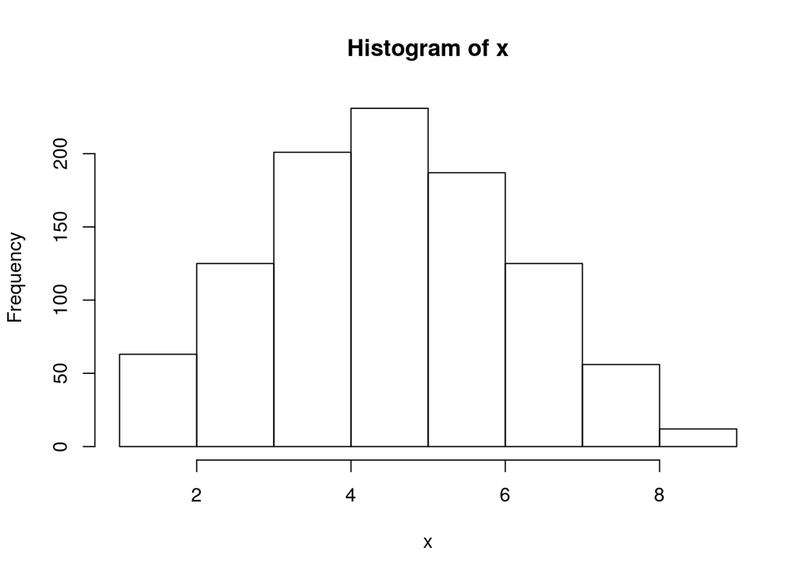

```r
hist(x)
```

```r
rm(x) # remove variable
```

For more information on distributions see http://cran.r-project.org/web/views/Distributions.html

# Piping for better style and readability

```r
# install.packages('magrittr')
library(magrittr)
```

```r
x <- rbinom(n=1000, size=10, prob=0.5)

x %>% var() # Instead of var(x)
```

```
## [1] 2.403
```

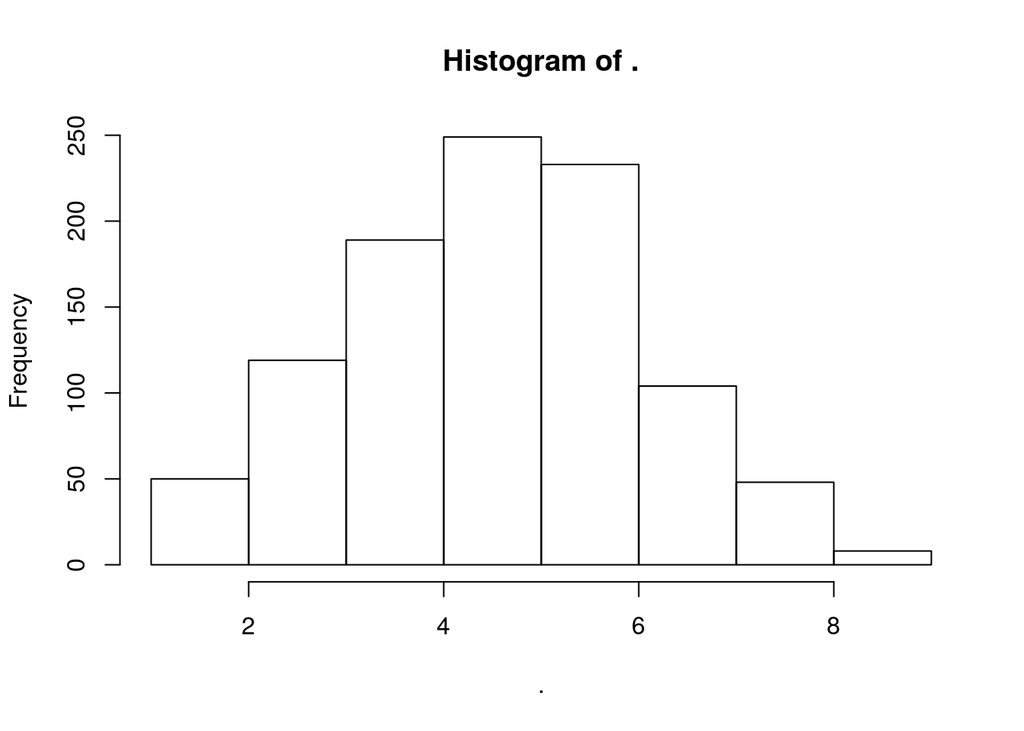

```r
x %>% hist()  # Instead of hist(x)
```

```r
x %>% mean() %>% round(2) %>% add(10)
```

```
## [1] 15.03
```

This example clearly demonstrates the benefits (from http://cran.r-project.org/web/packages/magrittr/vignettes/magrittr.html)

```r
# Old style
car_data <-
  transform(aggregate(. ~ cyl,
                      data = subset(mtcars, hp > 100),
                      FUN = function(x) round(mean(x, 2))),
            kpl = mpg*0.4251)


# magrittr style
car_data <-
  mtcars %>%
  subset(hp > 100) %>%
  aggregate(. ~ cyl, data = ., FUN = . %>% mean %>% round(2)) %>%
  transform(kpl = mpg %>% multiply_by(0.4251)) %>%
  print
```

```
##   cyl   mpg  disp    hp drat   wt  qsec   vs   am gear carb    kpl
## 1   4 25.90 108.0 111.0 3.94 2.15 17.75 1.00 1.00 4.50 2.00 11.010
## 2   6 19.74 183.3 122.3 3.59 3.12 17.98 0.57 0.43 3.86 3.43  8.391
## 3   8 15.10 353.1 209.2 3.23 4.00 16.77 0.00 0.14 3.29 3.50  6.419
```

# Variable creation and manipulation

```r
c(10, 11, 12, 13, 14, 15, 16, 17, 18, 19, 20, 21)
```

```
##  [1] 10 11 12 13 14 15 16 17 18 19 20 21
```

```r
10:21
```

```
##  [1] 10 11 12 13 14 15 16 17 18 19 20 21
```

```r
seq(from=10, to=21, by=1)
```

```
##  [1] 10 11 12 13 14 15 16 17 18 19 20 21
```

```r
seq(from=10, to=21, by=2)
```

```
## [1] 10 12 14 16 18 20
```

```r
x<-c(10, 11, 12, 13, 14, 15, 16, 17, 18, 19, 20, 21)
x
```

```
##  [1] 10 11 12 13 14 15 16 17 18 19 20 21
```

Non standard assignments

```r
c(1,2,3) ->y ; y
```

```
## [1] 1 2 3
```

```r
assign('y', c(1,2,3) ); y
```

```
## [1] 1 2 3
```

```r
assign('y', c(1,2,3), env=.GlobalEnv )
```

You can assign AFTER the computation is finished:

```r
c(1,2,3)
```

```
## [1] 1 2 3
```

```r
y<- .Last.value
y
```

[output not shown]

Operations usually work element-wise:

```r
x+2
```

```
##  [1] 12 13 14 15 16 17 18 19 20 21 22 23
```

```r
x*2
```

```
##  [1] 20 22 24 26 28 30 32 34 36 38 40 42
```

```r
x^2
```

```
##  [1] 100 121 144 169 196 225 256 289 324 361 400 441
```

```r
sqrt(x)
```

```
##  [1] 3.162 3.317 3.464 3.606 3.742 3.873 4.000 4.123 4.243 4.359 4.472
## [12] 4.583
```

```r
log(x)
```

```
##  [1] 2.303 2.398 2.485 2.565 2.639 2.708 2.773 2.833 2.890 2.944 2.996
## [12] 3.045
```

# Simple plotting

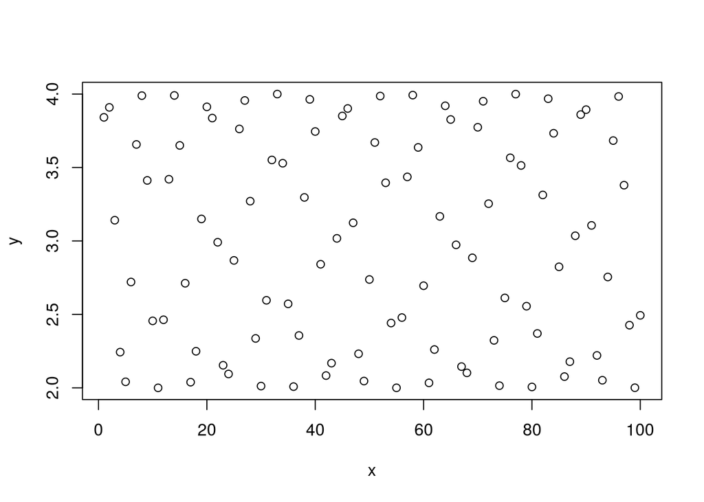

```r
x<- 1:100; y<- 3+sin(x) # Create arbitrary data
plot(x, y) # x,y syntax
```

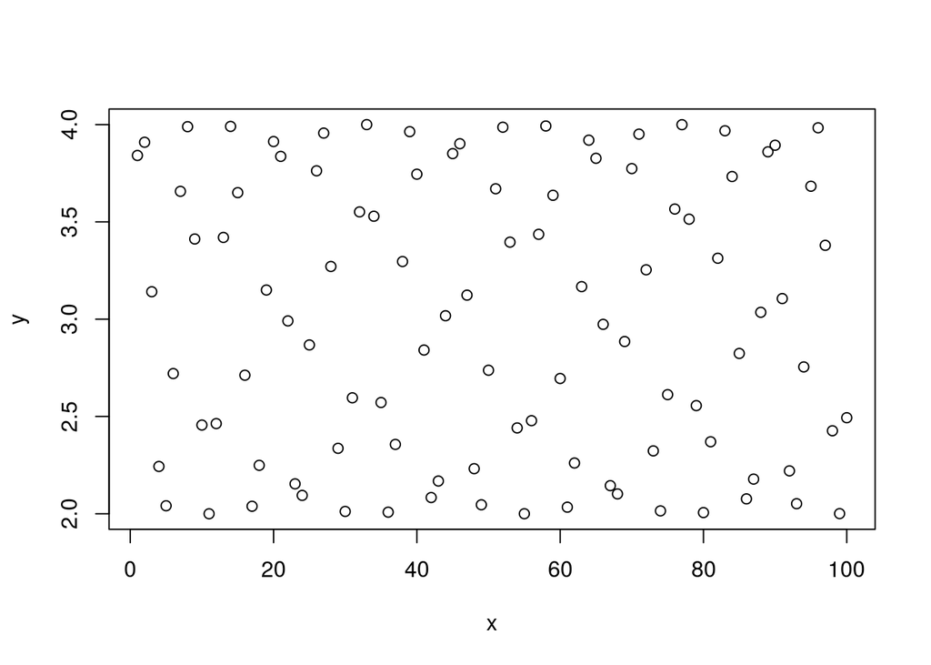

```r
plot(y~x) # y~x syntax (I like better)
```

Control plot appearance:

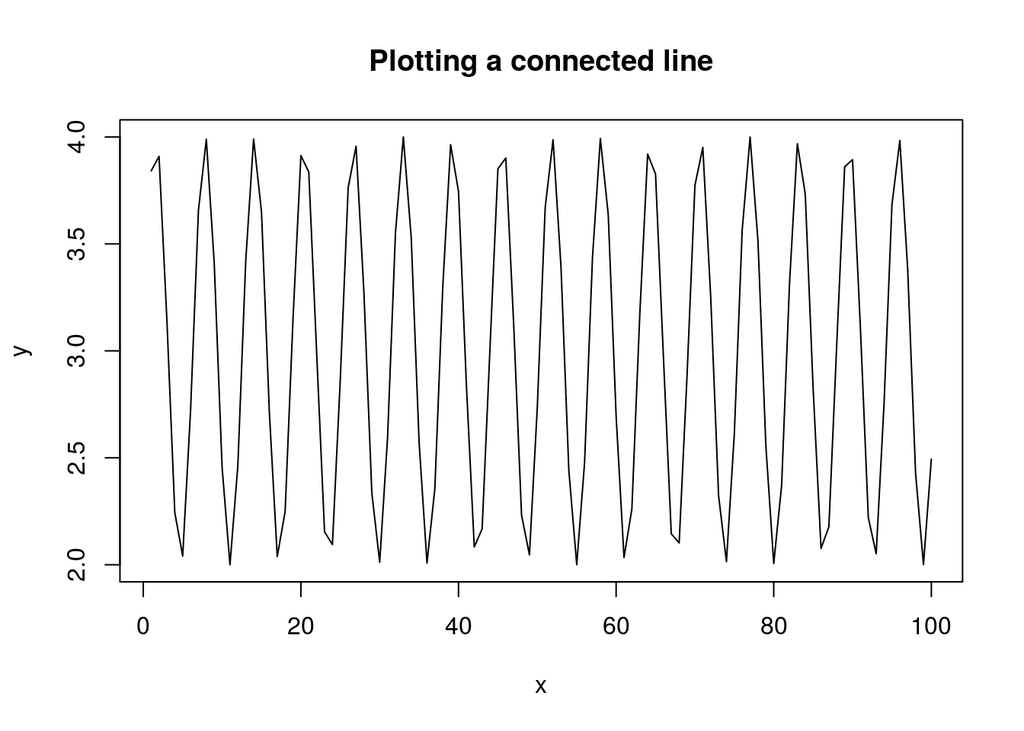

```r
plot(y~x, type='l', main='Plotting a connected line')
```

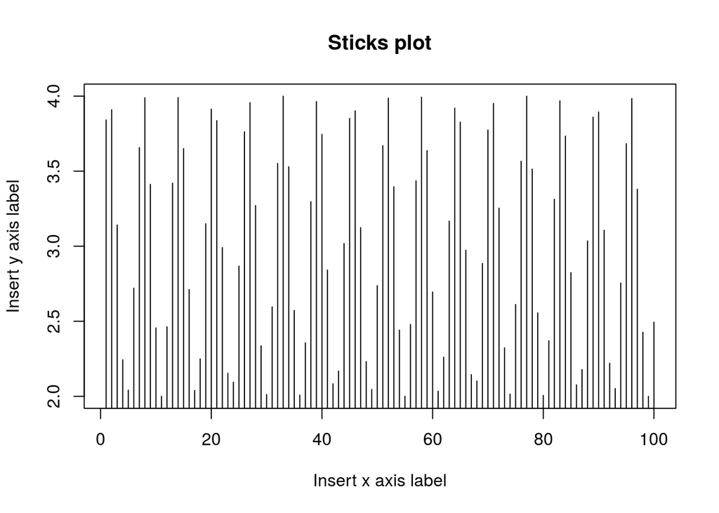

```r
plot(y~x, type='h', main='Sticks plot', xlab='Insert x axis label', ylab='Insert y axis label')
```

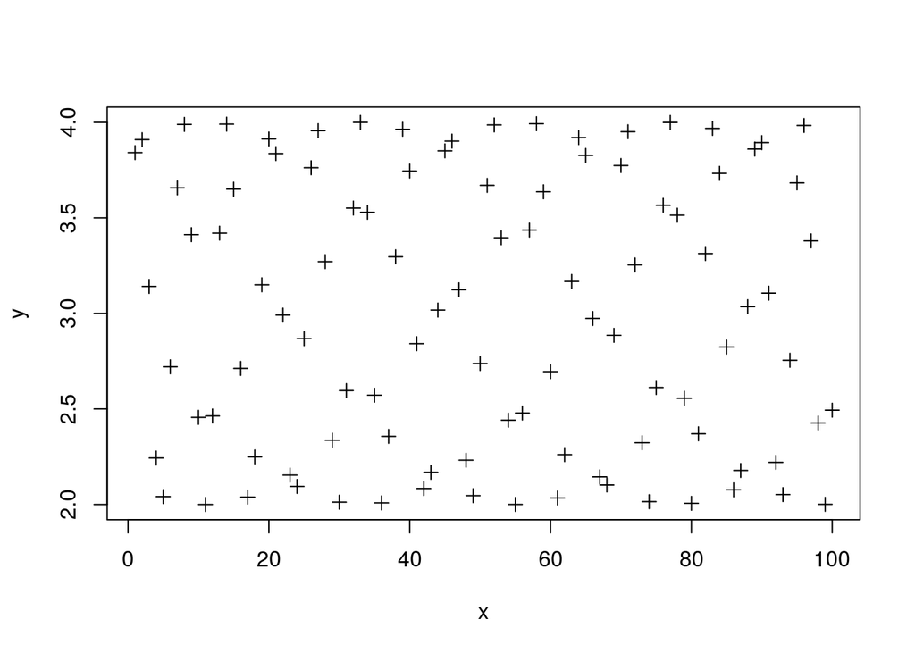

```r
plot(y~x, pch=3)
```

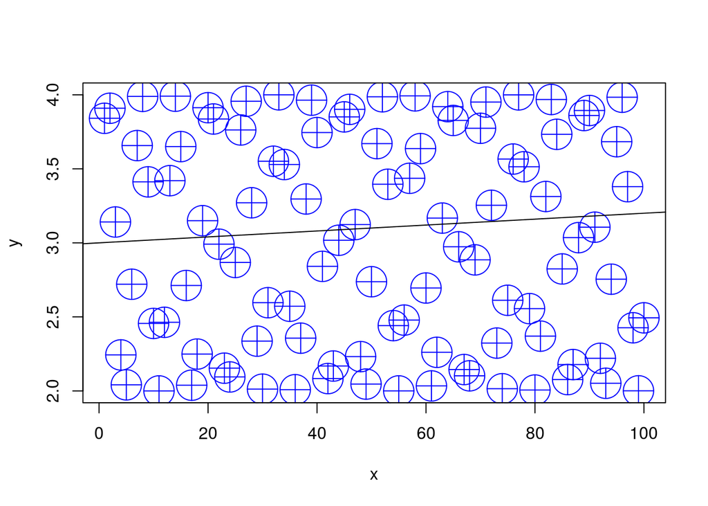

```r
plot(y~x, pch=10, type='p', col='blue', cex=4)
abline(3, 0.002)
```

```r
example(plot)
?plot
help(package='graphics')
```

When your plotting gets serious, move to ggplot2 and ggvis as soon as possible.

# Data frame Manipulation

```r
class(x) # R (high) level representation of an object.
```

```
## [1] "integer"
```

```r
mode(x)
```

```
## [1] "numeric"
```

```r
typeof(x)
```

```
## [1] "integer"
```

Create and checkout your first data frame:

```r
x<- 1:100; y<- 3+sin(x)
frame1 <- data.frame(x=x, sin=y)
frame1
```

```
##       x   sin
## 1     1 3.841
## 2     2 3.909
## 3     3 3.141
## 4     4 2.243
## 5     5 2.041
## 6     6 2.721
## 7     7 3.657
## 8     8 3.989
## 9     9 3.412
## 10   10 2.456
## 11   11 2.000
## 12   12 2.463
## 13   13 3.420
## 14   14 3.991
```

[output cut: 86 more lines]

```r
frame1 %>% head() # just print the beginning
```

```
##   x   sin
## 1 1 3.841
## 2 2 3.909
## 3 3 3.141
## 4 4 2.243
## 5 5 2.041
## 6 6 2.721
```

```r
frame1 %>% View() # Excel-like view (never edit!)
class(frame1)
```

```
## [1] "data.frame"
```

```r
dim(frame1)
```

```
## [1] 100   2
```

```r
dim(x)
```

[output not shown]

```r
length(frame1)
```

```
## [1] 2
```

```r
str(frame1) # the inner structure of an object
```

```
## 'data.frame':    100 obs. of  2 variables:
##  $ x  : int  1 2 3 4 5 6 7 8 9 10 ...
##  $ sin: num  3.84 3.91 3.14 2.24 2.04 ...
```

## Exctraction functions (will work on ANY object):

single element:

```r
frame1[1, 2]
```

```
## [1] 3.841
```

```r
frame1[2, 1]
```

```
## [1] 2
```

Exctract column by index:

```r
frame1[1, ]
```

```
##   x   sin
## 1 1 3.841
```

```r
t(frame1[, 1])
```

```
##      [,1] [,2] [,3] [,4] [,5] [,6] [,7] [,8] [,9] [,10] [,11] [,12] [,13]
## [1,]    1    2    3    4    5    6    7    8    9    10    11    12    13
##      [,14] [,15] [,16] [,17] [,18] [,19] [,20] [,21] [,22] [,23] [,24]
## [1,]    14    15    16    17    18    19    20    21    22    23    24
##      [,25] [,26] [,27] [,28] [,29] [,30] [,31] [,32] [,33] [,34] [,35]
## [1,]    25    26    27    28    29    30    31    32    33    34    35
##      [,36] [,37] [,38] [,39] [,40] [,41] [,42] [,43] [,44] [,45] [,46]
## [1,]    36    37    38    39    40    41    42    43    44    45    46
##      [,47] [,48] [,49] [,50] [,51] [,52] [,53] [,54] [,55] [,56] [,57]
## [1,]    47    48    49    50    51    52    53    54    55    56    57
##      [,58] [,59] [,60] [,61] [,62] [,63] [,64] [,65] [,66] [,67] [,68]
## [1,]    58    59    60    61    62    63    64    65    66    67    68
##      [,69] [,70] [,71] [,72] [,73] [,74] [,75] [,76] [,77] [,78] [,79]
## [1,]    69    70    71    72    73    74    75    76    77    78    79
##      [,80] [,81] [,82] [,83] [,84] [,85] [,86] [,87] [,88] [,89] [,90]
## [1,]    80    81    82    83    84    85    86    87    88    89    90
##      [,91] [,92] [,93] [,94] [,95] [,96] [,97] [,98] [,99] [,100]
## [1,]    91    92    93    94    95    96    97    98    99    100
```

```r
dim(t(frame1))
```

```
## [1]   2 100
```

Exctract column by name:

```r
names(frame1)
```

```
## [1] "x"   "sin"
```

```r
frame1[, 'sin']
```

```
##   [1] 3.841 3.909 3.141 2.243 2.041 2.721 3.657 3.989 3.412 2.456 2.000
##  [12] 2.463 3.420 3.991 3.650 2.712 2.039 2.249 3.150 3.913 3.837 2.991
##  [23] 2.154 2.094 2.868 3.763 3.956 3.271 2.336 2.012 2.596 3.551 4.000
##  [34] 3.529 2.572 2.008 2.356 3.296 3.964 3.745 2.841 2.083 2.168 3.018
##  [45] 3.851 3.902 3.124 2.232 2.046 2.738 3.670 3.987 3.396 2.441 2.000
##  [56] 2.478 3.436 3.993 3.637 2.695 2.034 2.261 3.167 3.920 3.827 2.973
##  [67] 2.144 2.102 2.885 3.774 3.951 3.254 2.323 2.015 2.612 3.566 4.000
##  [78] 3.514 2.556 2.006 2.370 3.313 3.968 3.733 2.824 2.077 2.178 3.035
##  [89] 3.860 3.894 3.106 2.221 2.052 2.755 3.683 3.984 3.380 2.427 2.001
## [100] 2.494
```

```r
dim(frame1[, 'sin'])
```

[output not shown]

```r
frame1['sin']
```

```
##       sin
## 1   3.841
## 2   3.909
## 3   3.141
## 4   2.243
## 5   2.041
## 6   2.721
## 7   3.657
## 8   3.989
## 9   3.412
## 10  2.456
## 11  2.000
## 12  2.463
## 13  3.420
## 14  3.991
```

[output cut: 86 more lines]

```r
dim(frame1['sin'])
```

```
## [1] 100   1
```

```r
frame1[, 2]
```

```
##   [1] 3.841 3.909 3.141 2.243 2.041 2.721 3.657 3.989 3.412 2.456 2.000
##  [12] 2.463 3.420 3.991 3.650 2.712 2.039 2.249 3.150 3.913 3.837 2.991
##  [23] 2.154 2.094 2.868 3.763 3.956 3.271 2.336 2.012 2.596 3.551 4.000
##  [34] 3.529 2.572 2.008 2.356 3.296 3.964 3.745 2.841 2.083 2.168 3.018
##  [45] 3.851 3.902 3.124 2.232 2.046 2.738 3.670 3.987 3.396 2.441 2.000
##  [56] 2.478 3.436 3.993 3.637 2.695 2.034 2.261 3.167 3.920 3.827 2.973
##  [67] 2.144 2.102 2.885 3.774 3.951 3.254 2.323 2.015 2.612 3.566 4.000
##  [78] 3.514 2.556 2.006 2.370 3.313 3.968 3.733 2.824 2.077 2.178 3.035
##  [89] 3.860 3.894 3.106 2.221 2.052 2.755 3.683 3.984 3.380 2.427 2.001
## [100] 2.494
```

```r
frame1[2]
```

```
##       sin
## 1   3.841
## 2   3.909
## 3   3.141
## 4   2.243
## 5   2.041
## 6   2.721
## 7   3.657
## 8   3.989
## 9   3.412
## 10  2.456
## 11  2.000
## 12  2.463
## 13  3.420
## 14  3.991
```

[output cut: 86 more lines]

```r
frame1[2, ]
```

```
##   x   sin
## 2 2 3.909
```

```r
frame1$sin
```

```
##   [1] 3.841 3.909 3.141 2.243 2.041 2.721 3.657 3.989 3.412 2.456 2.000
##  [12] 2.463 3.420 3.991 3.650 2.712 2.039 2.249 3.150 3.913 3.837 2.991
##  [23] 2.154 2.094 2.868 3.763 3.956 3.271 2.336 2.012 2.596 3.551 4.000
##  [34] 3.529 2.572 2.008 2.356 3.296 3.964 3.745 2.841 2.083 2.168 3.018
##  [45] 3.851 3.902 3.124 2.232 2.046 2.738 3.670 3.987 3.396 2.441 2.000
##  [56] 2.478 3.436 3.993 3.637 2.695 2.034 2.261 3.167 3.920 3.827 2.973
##  [67] 2.144 2.102 2.885 3.774 3.951 3.254 2.323 2.015 2.612 3.566 4.000
##  [78] 3.514 2.556 2.006 2.370 3.313 3.968 3.733 2.824 2.077 2.178 3.035
##  [89] 3.860 3.894 3.106 2.221 2.052 2.755 3.683 3.984 3.380 2.427 2.001
## [100] 2.494
```

```r
subset(frame1, select=sin)
```

```
##       sin
## 1   3.841
## 2   3.909
## 3   3.141
## 4   2.243
## 5   2.041
## 6   2.721
## 7   3.657
## 8   3.989
## 9   3.412
## 10  2.456
## 11  2.000
## 12  2.463
## 13  3.420
## 14  3.991
```

[output cut: 86 more lines]

```r
subset(frame1, select=2)
```

```
##       sin
## 1   3.841
## 2   3.909
## 3   3.141
## 4   2.243
## 5   2.041
## 6   2.721
## 7   3.657
## 8   3.989
## 9   3.412
## 10  2.456
## 11  2.000
## 12  2.463
## 13  3.420
## 14  3.991
```

[output cut: 86 more lines]

```r
subset(frame1, select=c(2,0))
```

```
##       sin
## 1   3.841
## 2   3.909
## 3   3.141
## 4   2.243
## 5   2.041
## 6   2.721
## 7   3.657
## 8   3.989
## 9   3.412
## 10  2.456
## 11  2.000
## 12  2.463
## 13  3.420
## 14  3.991
```

[output cut: 86 more lines]

**Sanity conservation notice** Note the difference between [] and [[]] exctraction!

```r
a <- frame1[1]
b <- frame1[[1]]
a==b
```

```
##           x
##   [1,] TRUE
##   [2,] TRUE
##   [3,] TRUE
##   [4,] TRUE
##   [5,] TRUE
##   [6,] TRUE
##   [7,] TRUE
##   [8,] TRUE
##   [9,] TRUE
##  [10,] TRUE
##  [11,] TRUE
##  [12,] TRUE
##  [13,] TRUE
##  [14,] TRUE
```

[output cut: 86 more lines]

```r
# Seems identical. But not really:
class(a)
```

```
## [1] "data.frame"
```

```r
class(b)
```

```
## [1] "integer"
```

```r
# Causes different behaviour:
a[1]
```

```
##       x
## 1     1
## 2     2
## 3     3
## 4     4
## 5     5
## 6     6
## 7     7
## 8     8
## 9     9
## 10   10
## 11   11
## 12   12
## 13   13
## 14   14
```

[output cut: 86 more lines]

```r
b[1]
```

```
## [1] 1
```

More about extraction: http://adv-r.had.co.nz/Subsetting.html

## dplyr package extension:

Very fast, fun and clarifies coding. Install the package:

```r
# install.packages('dplyr')
```

Now free an afternoon and go to: https://github.com/justmarkham/dplyr-tutorial/blob/master/dplyr-tutorial.Rmd

## Arrays

Arrays generalize matrices to higher dimension:

```r
x<- array(1:24, dim=c(6,4) )
x[6,4]
```

```
## [1] 24
```

```r
x<- array(1:24, dim=c(6,2,2) )
x[6,2,2]
```

```
## [1] 24
```

```r
x<- array(1:24, dim=c(2,3,2,2) )
x[2,3,2,2]
```

```
## [1] 24
```

# Data Import

For a complete review see: http://cran.r-project.org/doc/manuals/R-data.html or “Import and Export Manual” in help.start()

### Import from WEB

`read.table()` is the main importing workhorse.

```r
URL <- 'http://statweb.stanford.edu/~tibs/ElemStatLearn/datasets/bone.data'
tirgul1 <- read.table(URL)
```

Always look at the imported result!

```r
View(tirgul1)
# hmmm... header interpreted as data. Fix with header=TRUE:
tirgul1 <- read.table(URL, header = TRUE)
View(tirgul1)
```

### Import .csv files

Let’s write a simple file so that we have something to import:

```r
(temp.file.name <- tempfile())
```

```
## [1] "/tmp/RtmpHQs2sM/file3362384bae5e"
```

```r
View(airquality)
write.csv(x = airquality, file = temp.file.name)
```

Now let’s import:

```r
# my.data<- read.csv(file='/home/jonathan/Projects/...')
my.data<- read.csv(file=temp.file.name)
View(my.data)
```

**Note**: Under MS Windows(R) you might want need ‘\' instead of’/’

### Imprt .txt files

Tries to guess the seperator

```r
my.data<- read.table(file='C:\\Documents and Settings\\Jonathan\\My Documents\\...') #
```

Specifies the seperator explicitly

```r
my.data<- read.delim(file='C:\\Documents and Settings\\Jonathan\\My Documents\\...')
```

If you care about your sanity, see ?read.table before starting imports.

### Writing Data to files

Get and set the current directory:

```r
getwd() #What is the working directory?
setwd() #Setting the working directory in Linux
```

```r
write.csv(x=tirgul1, file='/tmp/tirgul1.csv') #
```

See ?write.table for details.

### .XLS files

Strongly recommended to convert to .csv If you still insist see: http://cran.r-project.org/doc/manuals/R-data.html#Reading-Excel-spreadsheets

### Massive files

Better store as matrices and not data.frames. `scan()` is faster than `read.table()` but less convenient:

Create the example data:

```r
cols<- 1e3
# Note: On Windoes you might neet to change /tmp/A.txt to /temp/A.txt
rnorm(cols^2) %>%
  matrix(ncol=cols) %>%
  write.table(file='/tmp/A.txt', col.names= F, row.names= F)
# Measure speed of import:
system.time(A<- read.table('/tmp/A.txt', header=F))
```

```
##    user  system elapsed
##   4.779   0.012   4.795
```

```r
system.time(A <- scan(file='/tmp/A.txt', n = cols^2) %>%
              matrix(ncol=cols, byrow = TRUE))
```

```
##    user  system elapsed
##   0.934   0.012   0.947
```

```r
file.remove('/tmp/A.txt')
```

```
## [1] TRUE
```

This matter will be revisited in the last class.

### Databases:

R can connect to all databases.

### Importing some real life data (from the WEB)

```r
names(tirgul1)
```

```
## [1] "idnum"  "age"    "gender" "spnbmd"
```

```r
tirgul1 %>% head
```

```
##   idnum   age gender   spnbmd
## 1     1 11.70   male 0.018081
## 2     1 12.70   male 0.060109
## 3     1 13.75   male 0.005858
## 4     2 13.25   male 0.010264
## 5     2 14.30   male 0.210526
## 6     2 15.30   male 0.040843
```

```r
tirgul1 %>% tail
```

```
##     idnum  age gender   spnbmd
## 480   379 13.6 female  0.05004
## 481   380 11.6   male  0.11637
## 482   381  9.8 female  0.09790
## 483   382 11.9   male  0.02899
## 484   383 11.2   male -0.06410
## 485   384  9.8 female  0.04991
```

```r
dim(tirgul1)
```

```
## [1] 485   4
```

```r
length(tirgul1)
```

```
## [1] 4
```

```r
# R can be object oriented (read about S3 and S4 if interested. But, not worth it.).
class(tirgul1[, 1]); class(tirgul1[, 2]); class(tirgul1[, 3]); class(tirgul1[, 4])
```

```
## [1] "integer"
```

```
## [1] "numeric"
```

```
## [1] "factor"
```

```
## [1] "numeric"
```

```r
summary(tirgul1)
```

```
##      idnum          age          gender        spnbmd
##  Min.   :  1   Min.   : 9.4   female:259   Min.   :-0.06410
##  1st Qu.: 60   1st Qu.:12.7   male  :226   1st Qu.: 0.00586
##  Median :124   Median :15.4                Median : 0.02659
##  Mean   :152   Mean   :16.1                Mean   : 0.03925
##  3rd Qu.:240   3rd Qu.:19.1                3rd Qu.: 0.06413
##  Max.   :384   Max.   :25.6                Max.   : 0.21991
```

# Matrix is more efficient. But can store only a single class.

tirgul.matrix <- as.matrix(tirgul1)  
tirgul.matrix class(tirgul.matrix) class(tirgul.matrix[, 1]); class(tirgul.matrix[, 2]); class(tirgul.matrix[, 3]); class(tirgul.matrix[, 4]) sapply(tirgul.matrix, class) # mapping functions. much more efficient. summary(tirgul.matrix)